# An Analysis of Chicago Taxi Trips

## Do taxi passengers tend to tip more for the company Chicago Independents than the other companies?

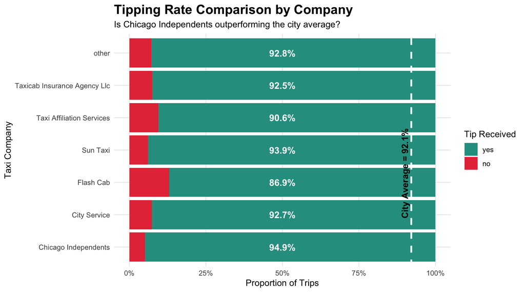

```r
# 1. Calculating the overall city average rate (as a decimal)
overall_rate <- mean(taxi$tip == "yes")

# 2. Calculating the tipping rate per company for the labels
company_stats <- taxi |>
  group_by(company) |>
  summarize(
    total_rides = n(),
    yes_count = sum(tip == "yes"),
    tip_rate = yes_count / total_rides
  )

company_stats <- company_stats |>
  arrange(desc(tip_rate))

# 3. Creating the Plot
ggplot(taxi, aes(y = company, fill = tip)) +
  # Creating the graph bar
  geom_bar(position = "fill") +
  # Adding the tip rate labels onto each bar
  geom_text(
    data = company_stats,
    aes(y = company, x = 0.5, label = percent(tip_rate, accuracy = 0.1)),
    inherit.aes = FALSE,
    color = "white",
    fontface = "bold",
    size = 4
  ) +
  # Adding the vertical line for the overall city average
  geom_vline(xintercept = overall_rate, linetype = "dashed", color = "white", size = 1) +
  # Annotating the line with the numerical value
  annotate(
    "text",
    x = overall_rate,
    y = 0.5,
    label = paste0("City Average = ", percent(overall_rate, accuracy = 0.1)),
    color = "black",
    vjust = -0.5,
    hjust = -0.5,
    angle = 90,
    fontface = "bold"
  ) +
  # Cleaning up scales and labels
  scale_x_continuous(labels = percent) +
  scale_fill_manual(values = c("no" = "#E63946", "yes" = "#2A9D8F")) + # Clean vector-style colors
  labs(
    title = "Tipping Rate Comparison by Company",
    subtitle = "Is Chicago Independents outperforming the city average?",
    x = "Proportion of Trips",
    y = "Taxi Company",
    fill = "Tip Received"
  ) +
  theme_minimal() +
  theme(
    panel.grid.minor = element_blank(),
    plot.title = element_text(face = "bold", size = 16)
  )
```

### Analysis of Tipping Rate Comparison

The data indicates that **Chicago Independents** has the highest tipping rate among all the taxi companies in the dataset.

1. Tipping Rate of **Chicago Independents** is relatively higher at **94.9%**, compared to the overall tipping rate average of all companies, which is **92.1%**.
2. When compared to other major comapnies, **Chicago Independents** outperforms **Flash Cab** by a wide margin of **7.9%** percentage points and edges out its closest competitor, **Sun Taxi** by **1.0%** percentage points.
3. However, **Chicago Independents** has a smaller volume of total rides 781 (**7.8%**), compared to giants like **Taxi Affiliation Services**, whose proportion of ride share is, **16.9%**. Nevertheless, **Chicago Independents’** proportional success in securing tips is superior.

Therefore, despite being a smaller player in terms of ride volume, the **Chicago Independents** maintain an above average rate of passenger tipping.